# R Notebook

# Front note

I will try write my scripts in `.rmd` file instead of `.r`. Cuz the experience from writing assignment #1 using `.rmd` makes me agree `.rmd` is better in terms of documentation.

# Chapter 1

Nothing to practice

# Chapter 2

Nothing to practice

# Chapter 3 Visualizing distributions

## 3.1 load data

Before choosing a normalization method, inspect data distributions.

```r
# load packages
library(GEOquery)
library(knitr)
library(dplyr)
library(tibble)
library(tidyverse)

# Define GSE number
gse <- "GSE119732"

# source helpter function
source("./supp_functions.R")

# Download data
fetch_geo_supp(gse = gse)

path <- file.path("data", gse)
files <- list.files(path, pattern = "\\.txt.gz$|\\.tsv.gz$|\\.csv.gz$",
                    full.names = TRUE, recursive = TRUE)
```

Raw table preview

```r
library(readr)

safe_read <- function(file) {
  # First attempt: read as TSV
  df <- tryCatch(
    readr::read_tsv(file, show_col_types = FALSE),
    error = function(e) NULL   # catch fatal errors
  )

  # If read_tsv failed entirely:
  if (is.null(df)) {
    message("TSV read failed — reading as space-delimited file instead.")
    return(readr::read_table(file, show_col_types = FALSE))
  }

  # If read_tsv returned but with parsing issues:
  probs <- problems(df)
  if (nrow(probs) > 0) {
    message("Parsing issues detected in TSV — reading as space-delimited file instead.")
    return(readr::read_table(file, show_col_types = FALSE))
  }

  # If everything was fine:
  return(df)
}

x <- safe_read(files[1])

kable_head(x[, 1:min(6, ncol(x))], 5, paste(gse,": raw table preview"))
```

GSE119732 : raw table preview

| gene_id | A1 | A2 | A3 | A4 | B1 |
| --- | --- | --- | --- | --- | --- |
| ENSG00000223972.5 | 0 | 0 | 0 | 0 | 0 |
| ENSG00000227232.5 | 79 | 119 | 84 | 50 | 80 |
| ENSG00000278267.1 | 17 | 10 | 22 | 19 | 19 |
| ENSG00000243485.4 | 0 | 0 | 0 | 0 | 0 |
| ENSG00000237613.2 | 0 | 0 | 0 | 0 | 0 |

## 3.2 Boxplots

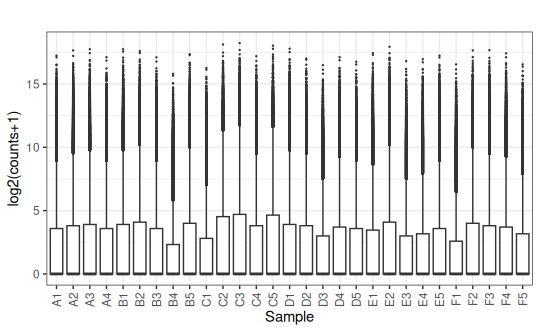

```r
library(tidyverse)

# suppose 'mat' is a gene x sample matrix (numeric)
plot_box <- function(mat, main = "", ylab = "log2(counts+1)") {
  df <- as.data.frame(mat)
  df_long <- df |>
    mutate(gene = rownames(df)) |>
    pivot_longer(-gene, names_to = "sample", values_to = "value") |>
    mutate(value = log2(value + 1))

  ggplot(df_long, aes(x = sample, y = value)) +
    geom_boxplot(outlier.size = 0.2) +
    theme_bw() +
    theme(axis.text.x = element_text(angle = 90, vjust = 0.5, hjust = 1)) +
    labs(title = main, x = "Sample", y = ylab)
}

plot_box(x[,2:ncol(x)])
```

3.3 Density plots

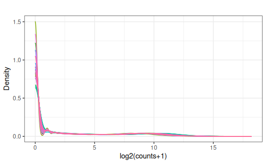

```r
plot_density <- function(mat, main = "") {
  df <- as.data.frame(mat)
  df_long <- df |>
    mutate(gene = rownames(df)) |>
    pivot_longer(-gene, names_to = "sample", values_to = "value") |>
    mutate(value = log2(value + 1))

  ggplot(df_long, aes(x = value, colour = sample)) +
    geom_density() +
    theme_bw() +
    labs(title = main, x = "log2(counts+1)", y = "Density") +
    guides(colour = "none")
}

plot_density(x[,2:ncol(x)])
```

# Chapter 4 Normalization method

## 4.1 Library-size scaling

The simplest approach divides each sample by its total counts (or reads) to account for sequencing depth

## 4.2 Distribution-based normalization

Methods like quantile normalization force sample distribution to match and common in microarrays

## RNA-seq composition-aware methods

Two widely used methods:

- TMM (edgeR): computes scaling factors to adjust effective library size.
- RLE/size factors (DESrq2): median-of-ratios approach

### edgeR: TMM

TMM looks at most genes, ignores the weird ones, figures out how different two samples really are, and uses that to scale the samples so they’re comparable.

```r
library(edgeR)

dge <- DGEList(counts = x)
dge <- calcNormFactors(dge, method = "TMM")
logcpm <- cpm(dge, log = TRUE, prior.count = 1)
```

### DESeq2: size factors

RLE finds what “most genes” are doing compared to a typical sample. It adjust each sample so that the median gene looks the same in all samples.

```r
library(DESeq2)

dds <- DESeqDataSetFromMatrix(countData = x, colData = meta, design = ~ condition)
```

```
Error in h(simpleError(msg, call)) :
  error in evaluating the argument 'x' in selecting a method for function 'nrow': object 'meta' not found
```

# Chapter 5 Worked normalization examples

## 5.1 Setup

```r
# Attach packages
library(GEOquery)
library(knitr)
library(dplyr)
library(tibble)
library(tidyverse)

gse <- "GSE119732"

source("./supp_functions.R")
fetch_geo_supp(gse = gse)

path <- file.path("data", gse)
files <- list.files(path, pattern = "\\.txt.gz$|\\.tsv.gz$|\\.csv.gz$",
                    full.names = TRUE, recursive = TRUE)
```

## 5.2 Raw table preview

```r
library(readr)

safe_read <- function(file) {
  # First attempt: read as TSV
  df <- tryCatch(
    readr::read_tsv(file, show_col_types = FALSE),
    error = function(e) NULL   # catch fatal errors
  )

  # If read_tsv failed entirely:
  if (is.null(df)) {
    message("TSV read failed — reading as space-delimited file instead.")
    return(readr::read_table(file, show_col_types = FALSE))
  }

  # If read_tsv returned but with parsing issues:
  probs <- problems(df)
  if (nrow(probs) > 0) {
    message("Parsing issues detected in TSV — reading as space-delimited file instead.")
    return(readr::read_table(file, show_col_types = FALSE))
  }

  # If everything was fine:
  return(df)
}

x <- safe_read(files[1])


kable_head(x[, 1:min(6, ncol(x))], 5, paste(gse,": raw table preview"))
```

GSE119732 : raw table preview

| gene_id | A1 | A2 | A3 | A4 | B1 |
| --- | --- | --- | --- | --- | --- |
| ENSG00000223972.5 | 0 | 0 | 0 | 0 | 0 |
| ENSG00000227232.5 | 79 | 119 | 84 | 50 | 80 |
| ENSG00000278267.1 | 17 | 10 | 22 | 19 | 19 |
| ENSG00000243485.4 | 0 | 0 | 0 | 0 | 0 |
| ENSG00000237613.2 | 0 | 0 | 0 | 0 | 0 |

## 5.3 Example 1: GSE119732

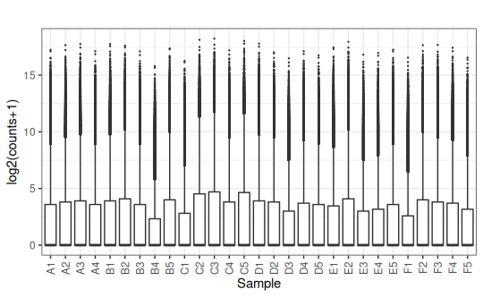

```r
plot_box(x[,2:ncol(x)])
```

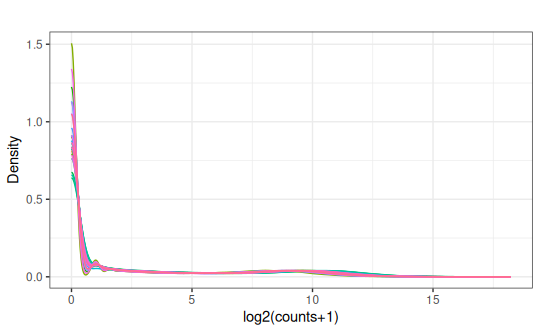

```r
plot_density(x[,2:ncol(x)])
```

## 5.4 convert raw counts to Counts per million (CPM)

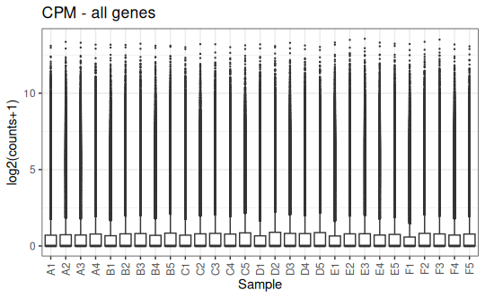

```r
library(edgeR)

x_cpm <- cpm(y = x[,2:ncol(x)])

plot_box(x_cpm,main = "CPM - all genes")
```

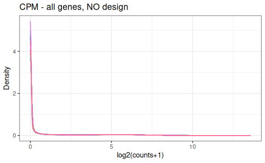

```r
plot_density(x_cpm,main = "CPM - all genes, NO design")
```

## 5.5 Filter out lowly expressed genes

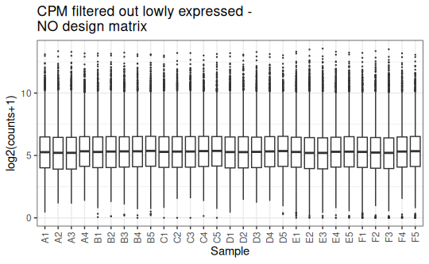

```r
to_remove <- edgeR::filterByExpr(x_cpm,min.count = 3)
x_cpm_filtered <- x_cpm[to_remove,]

plot_box(x_cpm_filtered,main = "CPM filtered out lowly expressed - \nNO design matrix")
```

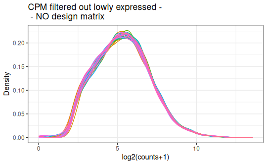

```r
plot_density(x_cpm_filtered,main = "CPM filtered out lowly expressed - \n - NO design matrix")
```

## 5.6 Incorporate a design matrix - description of the samples

```r
colnames(x)
```

```
 [1] "gene_id" "A1"      "A2"      "A3"      "A4"      "B1"
 [7] "B2"      "B3"      "B4"      "B5"      "C1"      "C2"
[13] "C3"      "C4"      "C5"      "D1"      "D2"      "D3"
[19] "D4"      "D5"      "E1"      "E2"      "E3"      "E4"
[25] "E5"      "F1"      "F2"      "F3"      "F4"      "F5"
```

```r
#design matrix -
samples <- colnames(x)[2:ncol(x)]
patient  <- substr(samples, 1, 1)
celltype <- substr(samples, 2, nchar(samples))
sample_data <- data.frame(samples, patient, celltype)


design <- model.matrix(~ 0 + celltype,data = sample_data)
rownames(design) <- sample_data$samples
colnames(design) <- paste0("celltype", levels(factor(celltype)))
design
```

```
   celltype1 celltype2 celltype3 celltype4 celltype5
A1         1         0         0         0         0
A2         0         1         0         0         0
A3         0         0         1         0         0
A4         0         0         0         1         0
B1         1         0         0         0         0
B2         0         1         0         0         0
B3         0         0         1         0         0
B4         0         0         0         1         0
B5         0         0         0         0         1
C1         1         0         0         0         0
C2         0         1         0         0         0
C3         0         0         1         0         0
C4         0         0         0         1         0
C5         0         0         0         0         1
D1         1         0         0         0         0
D2         0         1         0         0         0
D3         0         0         1         0         0
D4         0         0         0         1         0
D5         0         0         0         0         1
E1         1         0         0         0         0
E2         0         1         0         0         0
E3         0         0         1         0         0
E4         0         0         0         1         0
E5         0         0         0         0         1
F1         1         0         0         0         0
F2         0         1         0         0         0
F3         0         0         1         0         0
F4         0         0         0         1         0
F5         0         0         0         0         1
attr(,"assign")
[1] 1 1 1 1 1
attr(,"contrasts")
attr(,"contrasts")$celltype
[1] "contr.treatment"
```

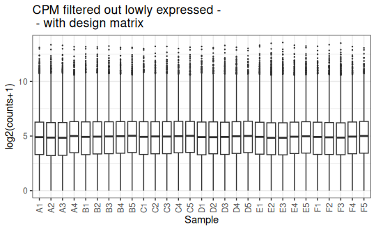

```r
# Filter use design information
to_remove_withdesign <- edgeR::filterByExpr(x_cpm,min.count = 3,
                                            design = design)
x_cpm_filtered_withdesign <- x_cpm[to_remove_withdesign,]

plot_box(x_cpm_filtered_withdesign,main = "CPM filtered out lowly expressed - \n - with design matrix")
```

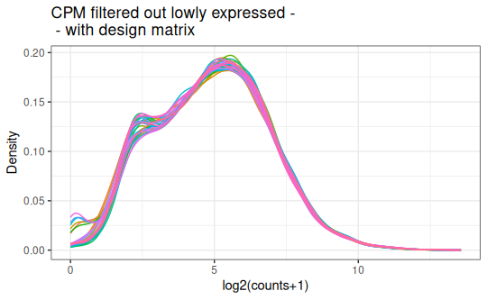

```r
plot_density(x_cpm_filtered_withdesign,main = "CPM filtered out lowly expressed - \n - with design matrix")
```

## 5.7 Normalize dataset using TMM

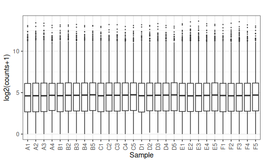

```r
library(edgeR)

dge <- DGEList(counts = x[,2:ncol(x)])
dge_filtered <- dge[filterByExpr(dge),]

dge_filtered  <- calcNormFactors(dge_filtered , method = "TMM")
norm_cpm <- cpm(dge_filtered , log = FALSE, prior.count = 1)

plot_box(norm_cpm)
```

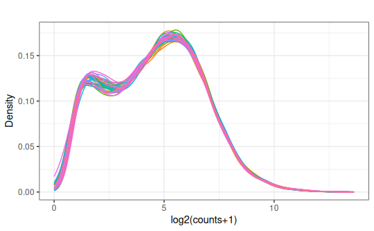

```r
plot_density(norm_cpm)
```

## 5.8 Look at distribution of our samples in 2D space

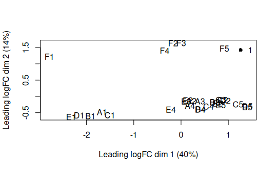

```r
y <- dge_filtered

plotMDS(y, top = 500, labels = colnames(y),
       col = as.integer(y$samples$group))
legend("topright", legend = levels(y$samples$group),
       col = seq_along(levels(y$samples$group)), pch = 16, bty = "n")
```

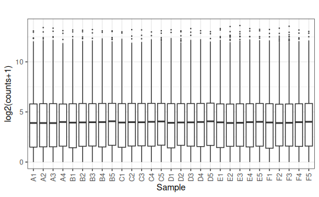

```r
# Incorporate the design into the process
dge <- DGEList(counts = x[,2:ncol(x)],group = sample_data$celltype)
dge_filtered <- dge[filterByExpr(dge),]
dge_filtered  <- calcNormFactors(dge_filtered , method = "TMM")
norm_cpm <- cpm(dge_filtered , log = FALSE, prior.count = 1)

plot_box(norm_cpm)
```

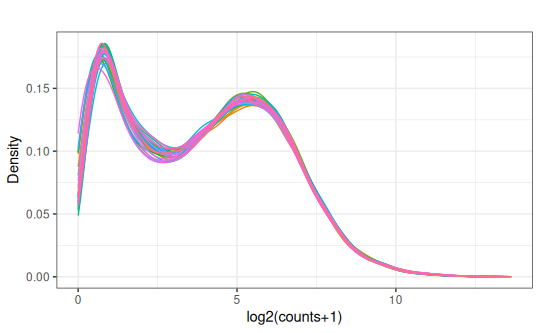

```r
plot_density(norm_cpm)
```

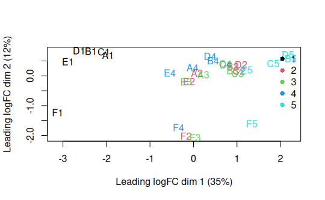

```r
y <- dge_filtered

plotMDS(y, top = 500, labels = colnames(y),
       col = as.integer(y$samples$group))
legend("topright", legend = levels(y$samples$group),
       col = seq_along(levels(y$samples$group)), pch = 16, bty = "n")
```

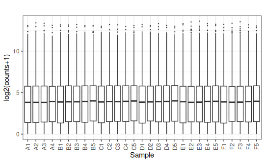

```r
# Incorporate the design into the process
dge <- DGEList(counts = x[,2:ncol(x)],group = sample_data$patient)
dge_filtered <- dge[filterByExpr(dge),]
dge_filtered  <- calcNormFactors(dge_filtered , method = "TMM")
norm_cpm <- cpm(dge_filtered , log = FALSE, prior.count = 1)

plot_box(norm_cpm)
```

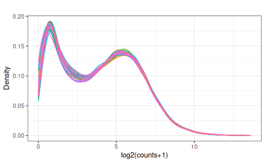

```r
plot_density(norm_cpm)
```

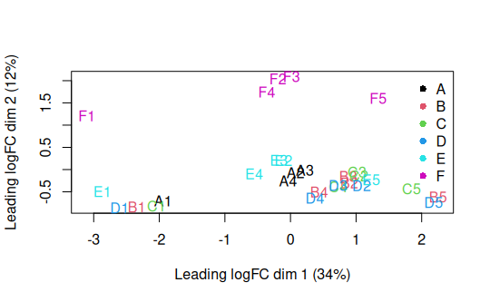

```r
y <- dge_filtered

plotMDS(y, top = 500, labels = colnames(y),
       col = as.integer(y$samples$group))
legend("topright", legend = levels(y$samples$group),
       col = seq_along(levels(y$samples$group)), pch = 16, bty = "n")
```

## 5.9 Normalize the Dataset using RLE

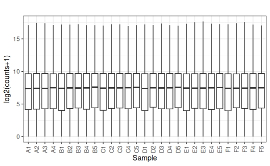

```r
library(DESeq2)

counts <- x[,2:ncol(x)]

keep <- rowSums(counts >= 10) >= 2
counts_filtered <- counts[keep, ]

dds <- DESeqDataSetFromMatrix(countData = counts_filtered,
                              colData = sample_data,
                              design = design)

dds <- estimateSizeFactors(dds)

norm_counts <- counts(dds, normalized = TRUE)

plot_box(norm_counts)
```

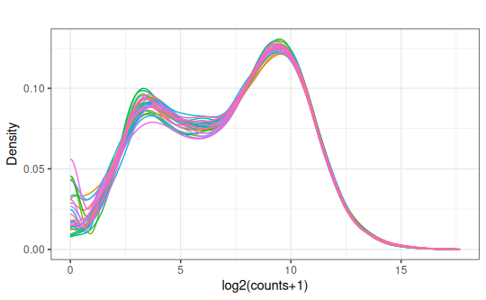

```r
plot_density(norm_counts)
```